# Data Science Capstone Week 3

Dawid J Duvenhage

October 12, 2017

### A1. Background

##### “In this capstone we will be applying data science in the area of natural language processing. As a first step toward working on this project, you should familiarize yourself with Natural Language Processing, Text Mining, and the associated tools in R. Here are some resources that may be helpful to you.”

#### Week 1 - Task 0 Understanding the problem:

##### https://www.coursera.org/learn/data-science-project/supplement/Iimbd/task-0-understanding-the-problem

##### The Data: https://d396qusza40orc.cloudfront.net/dsscapstone/dataset/Coursera-SwiftKey.zip

#### Tasks to accomplish:

##### 1. Obtaining the data - Can you download the data and load/manipulate it in R?

##### 2. Familiarizing yourself with NLP and text mining - Learn about the basics of natural language processing and how it relates to the data science process you have learned in the Data Science Specialization.

#### Week 1 - Task 1 Getting and Cleaning the Data:

##### https://www.coursera.org/learn/data-science-project/supplement/IbTUL/task-1-getting-and-cleaning-the-data

#### Tasks to accomplish:

##### 1. Tokenization - identifying appropriate tokens such as words, punctuation, and numbers. Writing a function that takes a file as input and returns a tokenized version of it.

##### 2. Profanity filtering - removing profanity and other words you do not want to predict.

#### Week 2 - Task 2 “Exploratory Data Analysis”"

##### https://www.coursera.org/learn/data-science-project/supplement/BePVz/task-2-exploratory-data-analysis

##### “The first step in building a predictive model for text is understanding the distribution and relationship between the words, tokens, and phrases in the text. The goal of this task is to understand the basic relationships you observe in the data and prepare to build your first linguistic models.”

#### Tasks to accomplish:

##### 1. Exploratory analysis - perform a thorough exploratory analysis of the data, understanding the distribution of words and relationship between the words in the corpora.

##### 2. Understand frequencies of words and word pairs - build figures and tables to understand variation in the frequencies of words and word pairs in the data.

#### Week 2 - “Task 3 Modeling”"

##### https://www.coursera.org/learn/data-science-project/supplement/2IiM9/task-3-modeling

##### 1. Build basic n-gram model - using the exploratory analysis you performed, build a basic n-gram model for predicting the next word based on the previous 1, 2, or 3 words.

##### 2. Build a model to handle unseen n-grams - in some cases people will want to type a combination of words that does not appear in the corpora. Build a model to handle cases where a particular n-gram isn’t observed.

#### Week 3 - “Task 4 Predictive Modeling”"

##### https://www.coursera.org/learn/data-science-project/supplement/SKIQt/task-4-prediction-model

##### The goal of this exercise is to build and evaluate your first predictive model. You will use the n-gram and backoff models you built in previous tasks to build and evaluate your predictive model. The goal is to make the model efficient and accurate.

##### 1. Build a predictive model based on the previous data modeling steps - you may combine the models in any way you think is appropriate.

##### 2. Evaluate the model for efficiency and accuracy - use timing software to evaluate the computational complexity of your model. Evaluate the model accuracy using different metrics like perplexity, accuracy at the first word, second word, and third word.

### A2. Resources used:

##### 1. https://cran.r-project.org/web/packages/ngram/ngram.pdf

##### 2. https://cran.r-project.org/web/packages/ngram/README.html

##### 3. https://cran.r-project.org/web/packages/tm/vignettes/tm.pdf

##### 4. http://www.cookbook-r.com/Graphs/Multiple_graphs_on_one_page_(ggplot2)/

##### 5. https://cran.r-project.org/web/packages/ngram/vignettes/ngram-guide.pdf

##### 6. https://cran.r-project.org/web/packages/quanteda/vignettes/quickstart.html

##### 7. http://beyondvalence.blogspot.com/2014/01/text-mining-4-performing-term.html

##### 8. https://www.r-bloggers.com/text-mining-the-complete-works-of-william-shakespeare/

##### 9. https://www.slideshare.net/rdatamining/text-mining-with-r-an-analysis-of-twitter-data

##### 10. http://www.sthda.com/english/wiki/text-mining-and-word-cloud-fundamentals-in-r-5-simple-steps-you-should-know

## ————————————————————————————-

### B. Basic Environment Setup

### B1. Loading libraries

### B2. Load cookbook-r.com ggplot 2 Helper Function for Multiple plot panel

## ————————————————————————————-

### C. Data Mining

### Step C1: File and Data Setup

#### 1.1 Set working directory, file paths, and download the data.

#### 1.2 Read raw training and profane table data.

### Step C2: Raw Data Exploration

#### 2.1 Evaluate object.size in MB, obtain file summary (length, class, mode), and inspect the first line in the text files:

```
##    NewsMB   BlogsMB TwitterMB   TotalMB
##  19.17972 248.49350 301.39670 569.06992
```

```
## $NewsSummary
##    Length     Class      Mode
##     77259 character character
##
## $BlogsSummary
##    Length     Class      Mode
##    899288 character character
##
## $TwitterSummary
##    Length     Class      Mode
##   2360148 character character
```

```
## $NewsSample
## [1] "He wasn't home alone, apparently."
##
## $BlogsSample
## [1] "In the years thereafter, most of the Oil fields and platforms were named after pagan gods."
##
## $TwitterSample
## [1] "How are you? Btw thanks for the RT. You gonna be in DC anytime soon? Love to see you. Been way, way too long."
```

#### 2.2 Number of lines per file:

```
##       news      blogs    twitter totalLines
##      77259     899288    2360148    3336695
```

#### 2.3 Number of words per file:

#### (note: this step takes a few minutes)

```
##    newsWords    blogWords twitterWords   totalWords
##      2643969     37334131     30373543     70351643
```

### Step C3. Create single reduce raw data file and Remove non-ASCII characters

##### Reduce the total raw data file size to 3000 lines total, i.e. 1000 each from news, blogs, and twitter and then confirm line count as 1000 lines per object.

##### By removing the non-ASCII characters we can safely assume that the remaining words are largely of the English language. While the ASCII code primarily represents English characters and numbers, other European languages also have English letter characters. Hence, this data cleanup is not comprehensive in the sense of foreign language clean up.

##### See attached references:

##### https://www.quora.com/What-is-the-difference-between-ASCII-and-unicode-characters-difference-between-UTF-8-and-UTF-16

##### https://docs.oracle.com/cd/B19306_01/server.102/b14225/ch2charset.htm

```
##    newsReduced   blogsReduced twitterReduced   totalReduced
##           1000           1000           1000           3000
```

#### Create a single combined truncated data object and remove any non-ASCII characters before creating Corpus.

```r
comb_trunc <- c(news_trunc, blogs_trunc, twitter_trunc)
comb_trunc <- iconv(comb_trunc, "latin1", "ASCII", sub="")
```

### Step C4: Create Corpus

##### Load the data as a corpus and inspect lines 4 to 6, then clean up the memory. Ask R to return memory to the operating system while releasing objects that are no longer in used (Only the first “memory clearing” instance is snowed below. Instances further down in the code are hidden).

##### See interesting section on memory leaks: http://adv-r.had.co.nz/memory.html

```r
combCorpus <- Corpus(VectorSource(comb_trunc))
        inspect(combCorpus[4:6])
```

```
## <<SimpleCorpus>>
## Metadata:  corpus specific: 1, document level (indexed): 0
## Content:  documents: 3
##
## [1] In your case, online statements have made it easier to access information at your convenience, which is a good thing. The column aimed to drive home the point that paperless users need to stay on top of their various accounts more vigorously than those who don't bother to manage their finance…
## [2] Radon. A naturally occurring radioactive gas, it's a byproduct of the breakdown of uranium and is the second leading cause of lung cancer in the United States, he says. "It comes up out of the soil, hits the foundation and comes up into the homes and builds up to dangerous levels in the indoo…
## [3] During a visit to Lithuania, U.S. Sen. John McCain joined the chorus calling for Tymoshenko to receive urgent medical care. McCain also said Ukraine's leadership cannot expect closer relations with Europe while it persecutes political opponents and fails to hold free and fair elections.
```

#### Object memory cleared and memory released:

```r
rm(news_trunc, blogs_trunc, twitter_trunc, comb_trunc)
gc()
```

```
##            used  (Mb) gc trigger   (Mb)  max used   (Mb)
## Ncells  4983685 266.2   14442815  771.4  11669884  623.3
## Vcells 66072047 504.1  208073441 1587.5 173327862 1322.4
```

### Step C5: Text Transformation

##### For this assignment “cleaning up the text data” follows an uncondensed “Stepwise Text Transformation”" so each step can be inspected.

##### The memory for each of the individually created data objects is cleared as soon as it is not further used.

#### 5.1 Removing special characters:

```r
toSpace <- content_transformer(function (x , pattern ) gsub(pattern, " ", x))
           combCorpusS <- tm_map(combCorpus, toSpace, "/")
           combCorpusS <- tm_map(combCorpus, toSpace, "@")
```

#### 5.2 Convert the text to lower case:

```r
combCorpusSL <- tm_map(combCorpusS, content_transformer(tolower))
#One can Inspect the corpus objects
#inspect(combCorpusSL)
```

#### 5.3 Remove numbers:

```r
combCorpusSLN <- tm_map(combCorpusSL, content_transformer(removeNumbers))
```

#### 5.4 Remove English common stop words:

```r
combCorpusSLNS <- tm_map(combCorpusSLN, removeWords, stopwords("english"))
```

#### 5.5 Remove profane words:

```r
names(profane)<-"profane"
combCorpusSLNSP <- tm_map(combCorpusSLNS, removeWords, profane[,1])
```

#### 5.6 Remove punctuations:

```r
combCorpusSLNSPP <- tm_map(combCorpusSLNSP, content_transformer(removePunctuation))
```

#### 5.7 Eliminate extra white spaces:

```r
combCorpusSLNSPPW <- tm_map(combCorpusSLNSPP, content_transformer(stripWhitespace))
```

#### 5.8 Text stemming:

##### Removing suffixes from words to get the common origin.

##### Stemming is a way to improve / increase word coverage, i.e. keep memory use lower.

```r
combCorpusSLNSPPWSt <- tm_map(combCorpusSLNSPPW, content_transformer(stemDocument))
```

#### 5.9 Write CLEANED corpus to disk (still includes sparse terms)

##### Optional step.

```r
#writeCorpus(combCorpusSLNSPPWSt)
```

## ————————————————————————————-

### D. Tokenize using ngram package

#### Step D1. Create a string of the cleaned corpus

##### Perform Tokenization, and thus obtain one (uni-), two (bi-), three (tri-), and four (tetra-) word combinations that appear frequently.

```r
strCorpus <- concatenate ( lapply (combCorpusSLNSPPWSt , "[", 1) )
        ng1 <- ngram(strCorpus, n=1)
        ng2 <- ngram(strCorpus, n=2)
        ng3 <- ngram(strCorpus, n=3)
        ng4 <- ngram(strCorpus, n=4)
```

#### Step D2. Inspect strCorpus data

##### Take a look at the first five entries in each of the ngrams generated.

##### other helper functions that can be used to inspect the corpus include:

##### (i) print(ng2, output=“full”) & get.phrasetable(ng2) &

##### (ii) To make new sentences use: babble(ng=ng2, genlen=12, seed= 101562)

```r
head(get.phrasetable(ngram(strCorpus, n=1)), 5)
```

```
##   ngrams freq        prop
## 1  said   304 0.006414585
## 2  like   280 0.005908170
## 3   one   268 0.005654963
## 4  will   266 0.005612762
## 5  just   251 0.005296253
```

```r
head(get.phrasetable(ngram(strCorpus, n=2)), 5)
```

```
##        ngrams freq         prop
## 1   new york    26 0.0005486274
## 2  last year    22 0.0004642232
## 3 last night    16 0.0003376168
## 4  right now    15 0.0003165158
## 5  feel like    14 0.0002954147
```

```r
head(get.phrasetable(ngram(strCorpus, n=3)), 5)
```

```
##               ngrams freq         prop
## 1     cinco de mayo     5 1.055075e-04
## 2 cricket world cup     4 8.440599e-05
## 3   osama bin laden     4 8.440599e-05
## 4     new york citi     4 8.440599e-05
## 5    want make sure     3 6.330449e-05
```

```r
head(get.phrasetable(ngram(strCorpus, n=4)), 5)
```

```
##                        ngrams freq         prop
## 1      cricket world cup dvd     3 6.330583e-05
## 2  overal hire remain strong     2 4.220389e-05
## 3 littl stage puppet theater     2 4.220389e-05
## 4    roman cathol code canon     2 4.220389e-05
## 5        done unto us believ     2 4.220389e-05
```

#### Step D3. Extract top 20 uni-, bi-, tri-, and tetra- grams for visual evaluation and plot

##### Make a multi panel plot using code obtained from cookbook-r.com

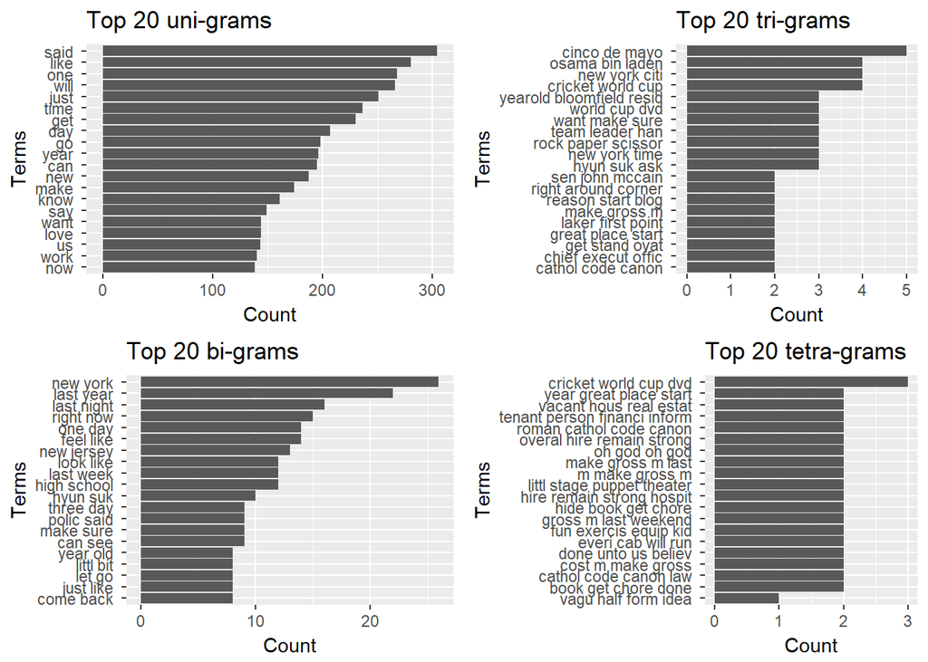

#### 4.3 Word Coverage

##### Word coverage per available memory can be improved through stemming, removing redundant sparse terms, and potentially dropping two letter words.

```r
#Setup the function to help extract the word coverage information
getCoverage <- function (unigram, coverage)
        {
         #start with zero frequency
         frequency <- 0
         #determined final coverage frequency from unigram
         coverageFrequency <- coverage * sum(unigram$freq)
         #the unigram information already comes sorted
         for (i in 1:nrow(unigram)) {
                 if (frequency >= coverageFrequency)

                 {
                  return (i)
                 }
                 frequency <- frequency + unigram[i, "freq"]
                                     }
         return (nrow(unigram))
        }

#Setup the unigram dictionary with column names from string corpus
unigram <- get.phrasetable(ngram(strCorpus, n=1))
```

```r
#Request the coverages
getCoverage(unigram, coverage= 0.5)
```

```
## [1] 598
```

```r
getCoverage(unigram, coverage= 0.9)
```

```
## [1] 5092
```

## ————————————————————————————-

### E. Term Document Matrix’s (tdm)

#### Step E1. Build the matrix

##### Use TermDocumentMatrix (or DocumentTermMatrix) depending on whether you want terms as rows and documents as columns, or vice versa.

#### Step E2. Inspect the tdm

##### There are several other ways to inspect the term-document matrix:

##### (i) View(as.matrix(tdm[1:1000, 1:5])) & inspect(dtm[1:2]) & meta(dtm[[2]], “id”) &

##### (ii) identical(dtm[[2]], dtm[[“dtm.txt”]]) & inspect(dtm[[2]]) & lapply(dtm[1:2], as.character)

```r
dtm <- TermDocumentMatrix(combCorpusSLNSPPWSt)
dim(dtm)
```

```
## [1] 9626 3000
```

```r
inspect(dtm[1:10,])
```

```
## <<TermDocumentMatrix (terms: 10, documents: 3000)>>
## Non-/sparse entries: 99/29901
## Sparsity           : 100%
## Maximal term length: 7
## Weighting          : term frequency (tf)
## Sample             :
##          Docs
## Terms     1 1077 1099 1439 1566 1613 1859 1982 5 677
##   absent  1    0    0    0    0    0    0    0 0   0
##   alga    3    0    0    0    0    3    0    0 0   0
##   captrad 1    0    0    0    0    0    0    0 0   0
##   claim   1    0    0    0    0    0    3    0 0   0
##   coal    1    0    0    0    0    0    0    0 0   0
##   cours   1    0    2    0    2    0    0    2 0   0
##   gas     1    0    0    0    0    0    0    0 1   1
##   natur   1    0    1    0    0    0    0    1 1   1
##   obama   1    2    0    2    0    0    0    0 0   0
##   oil     1    0    0    0    0    0    0    0 0   0
```

```r
findFreqTerms(dtm, 100)    #also use: findAssocs(dtm, "word to associate with", 0.8)
```

```
##  [1] "say"   "get"   "just"  "time"  "way"   "good"  "need"  "now"
##  [9] "said"  "come"  "also"  "much"  "one"   "will"  "can"   "last"
## [17] "two"   "week"  "work"  "think" "like"  "make"  "new"   "first"
## [25] "year"  "right" "peopl" "use"   "know"  "look"  "want"  "day"
## [33] "see"   "love"
```

#### Step E3. Evaluate sparsity and remove sparse terms

##### It appears that manipulation of sparse terms may in some instances impact the way the term document matrix respond to the word cloud analysis. It was opted not to include removal of sparse terms for the moment.

```r
#Removing those terms at least 95% sparse (i.e. terms occurring 0 times in a document)
#dtm <- removeSparseTerms(dtm, 0.95)
#str(dtm)                                 #also use: inspect(removeSparseTerms(dtm, 0.95))
```

#### Step E4. Evaluate the term document matrix

#### 4.1 Plotting Word Cloud

##### Create a suitable work matrix, inspect the data, and create a Word Cloud representing the 120 most frequent used words in term document matrix.

```
##      word freq
## said said  304
## like like  280
## one   one  268
## will will  266
## just just  251
## time time  236
## get   get  230
## day   day  207
## year year  196
## can   can  195
```

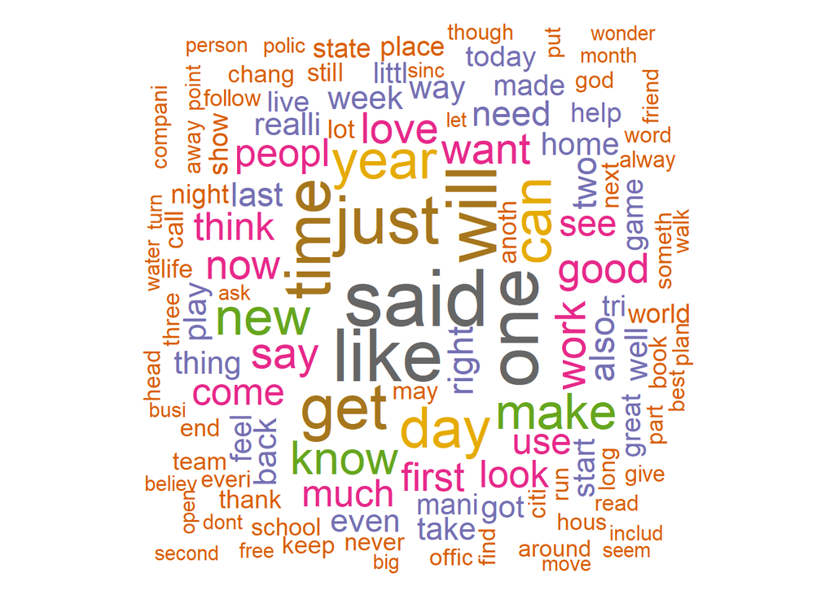

#### 4.2 Word Frequency analysis

[figure not shown]

## ————————————————————————————-

### F. Model Development - Markov chain algorithm

#### The plan going forward.

##### Basically the plan is to extract the individual words from the bi-, tri-, and tetra- grams as individually accessible entities that can be stored, searched, and recovered on request via a very basic Markov chainlike algorithm arrangement.

##### For instance, if the user, in the Shiny App, types the first word, the word will be first tested against the uni-gram to determine if the word is in the ng-database. If absent, no predicted choice is offered.

##### However, if the word is present in the uni-gram database, the word will first be tested against the first word entries in the tetra-gram. The reason to start the search in the tetra-gram is, if present in the tetra-gram database, will return the highest predicted word coverage, i.e. three words following the first word in the tetra-gram.

##### If there is no corresponding first word in the tetra-gram the search will expanded to the first word in the tri-gram database, and if not found there, access the bi-gram data base.

##### On which ever search the first word is allocated, the representing second, third, and fourth word will be offered to the user as an option to pick from. If the user picks a word, the search process highlighted above is repeated on the chosen word. If the user does not pick one of the presented options, and type a new word, the same process is repeated on the new word entered.

# _____________________________________________________________________________

#### Step F1. Prepare uni-, di-, tri-, and tetra- word phrase databasis and place holders

```r
                                                                      ###### REMEMBER TO REMOVE THE HEADS HERE ###########
#Create uni-phrase table from strCorpus
ng1All <- get.phrasetable(ngram(strCorpus, n=1))
#Extract all the uni-names
ng1AllNames <- ng1All$ngrams
#Place uni-names into a data frame
ng1DB <- as.data.frame(do.call(rbind, strsplit(ng1AllNames, ' ')))     #head(do.call(rbind, strsplit(ng1AllNames, ' '))))
#Name the data frame columns
colnames(ng1DB) <- c("word1")

#Create bi-phrase table from strCorpus
ng2All <- get.phrasetable(ngram(strCorpus, n=2))
#Extract all the bi-names
ng2AllNames <- ng2All$ngrams
#Place bi-names into a data frame
ng2DB <- as.data.frame(do.call(rbind, strsplit(ng2AllNames, ' ')))     #head(do.call(rbind, strsplit(ng2AllNames, ' '))))
#Name the data frame columns
colnames(ng2DB) <- c("word1", "word2")

#Create tri-phrase table from strCorpus
ng3All <- get.phrasetable(ngram(strCorpus, n=3))
#Extract all the tri-names
ng3AllNames <- ng3All$ngrams
#Place tri-names into a data frame
ng3DB <- as.data.frame(do.call(rbind, strsplit(ng3AllNames, ' ')))     #head(do.call(rbind, strsplit(ng3AllNames, ' '))))
#Name the data frame columns
colnames(ng3DB) <- c("word1", "word2", "word3")

#Create tetra-phrase table from strCorpus
ng4All <- get.phrasetable(ngram(strCorpus, n=4))
#Extract all the tetra-names
ng4AllNames <- ng4All$ngrams
#Place tetra-names into a data frame
ng4DB <- as.data.frame(do.call(rbind, strsplit(ng4AllNames, ' ')))     #head(do.call(rbind, strsplit(ng4AllNames, ' '))))
#Name the data frame columns
colnames(ng4DB) <- c("word1", "word2", "word3", "word4")


#Create an empty character vector to catch word choices and final word choices:
myWord4 <- as.data.frame(matrix(ncol=3), stringsAsFactors=FALSE)
colnames(myWord4) <- c("word2", "word3", "word4")

myWord3 <- as.data.frame(matrix(ncol=2), stringsAsFactors=FALSE)
colnames(myWord3) <- c("word2", "word3")

myWord2 <- as.data.frame(matrix(ncol=1), stringsAsFactors=FALSE)
colnames(myWord2) <- c("word2")

#Place holder for word choices offered to the user
myWordChoice <- as.data.frame(matrix(ncol=1, nrow= 5), stringsAsFactors=FALSE)
rownames(myWordChoice) <- c("word2", "word3", "word4", "askForUserEntry","wantToExit")
myWordChoice[4,1] <- ("")
myWordChoice[5,1] <- ("ex")


#Place holders for sentence being created
newWordChoice <- as.character()
mySentence <- as.character()
```

# _____________________________________________________________________________

#### Step F2. Extract on request the associated words from uni-, bi-, tri-, and tetra-grams.

##### Ask for a word and check that the word is in the uni-gram before proceeding

```r
#User input to request a word:
#****************************

myWordstart <-  "done"  #readline(prompt="Enter a word to start the sentence:")

        #Add the "myWord" to mySentence character string
        mySentence <- append(mySentence, myWordstart)

        #Check if User input is present in unigram
        if    ((!myWordstart %in% ng1DB$word1) == TRUE) {

                #If User input not present in unigram ask for next word
                myWordstart <- readline(prompt="I do not know that one, give me another word: ")

                        #Add the "myWord" to mySentence character string
                        mySentence <- append(mySentence, myWordstart)
```

[output not shown]

#### Step F3. Check if User selection from offered choices do not request a new word or to exit the program.

##### If new word is requested repeat process in Step F2.

##### If option is to “exit” exit code, printing the final sentence.

##### When the user entries are tested against, and found in uni-, bi-, tri-, and tetra-grams, the relevant word phrase is extracted, and then each indiviual word assigned to the objects word1, word2, word3, and word5 as applicable. The user is offered the option to choose from these words what the next word would be, and show the sentence as it is developing. If there is no suitable word to use from the prediction, allow the user to enter another word, and repeat the formentioned procedure till the user ask to exit. On exit the final senetence is printed.

```r
#Check if User input is present in uni-, bi-, tri-, and tetra-grams:
#Append word selection place holders
#******************************************************************
        } else
                myWord <- myWordstart

                while (!"ex" == newWordChoice) {

                        if    ("" == newWordChoice) {

                                myWord <-   readline(prompt="Enter a word to start the sentence:")  #"done"

                                        #Add the "myWord" to mySentence character string
                                        mySentence <- append(mySentence, myWord)

                                        #Check if User input is present in unigram
                                        if    (!myWord %in% ng1DB$word1) {

                                                #If User input not present in unigram ask for next word
                                                 myWord <- readline(prompt="I do not know that one, give me another word: ")

                                                #Add the "myWord" to mySentence character string
                                                mySentence <- append(mySentence, myWord)
                                        }


                        } else
                                #Clear word selection objects
                                myWord2 <- myWord2[0,]
                                myWord3 <- myWord3[0,]
                                myWord4 <- myWord4[0,]

                                #Clear myWordChoice and reestablish an empty data frame
                                myWordChoice <- as.character()
                                myWordChoice <- as.data.frame(matrix(ncol=1, nrow= 5), stringsAsFactors=FALSE)
                                rownames(myWordChoice) <- c("word2", "word3", "word4", "askForUserEntry","wantToExit")
                                #myWordChoice[4,1] <- ("")
                                #myWordChoice[5,1] <- ("ex")

                                #Add the "myWord" and "newWordChoice" to mySentence character string
                                mySentence <- append(mySentence,newWordChoice)
                                mySentence <- append(mySentence, myWord)

                                #check if the word is in tetra-, then tri-, then bi- gram
                                #with this approach go for maximum related wors to user input word
                                #check if the word is in tetra-gram
                                if
                                        (myWord %in% ng4DB$word1) {

                                        j = 1
                                                for (i in 1:nrow(ng4DB)) {
                                                        if ((ng4DB$word1[i] == myWord) == FALSE) {
                                                        next(i)
                                                } else {
                                                        myWord4[j,1] <-  as.data.frame(as.list(as.character(ng4DB$word2[i])), stringsAsFactors=FALSE)
                                                        myWord4[j,2] <-  as.data.frame(as.list(as.character(ng4DB$word3[i])), stringsAsFactors=FALSE)
                                                        myWord4[j,3] <-  as.data.frame(as.list(as.character(ng4DB$word4[i])), stringsAsFactors=FALSE)
                                                j = j + 1
                                                next(i)
                                                        }
                                                }

                                        myWordChoice[1,1] <- append(myWordChoice, myWord4$word2)
                                        myWordChoice[2,1] <- append(myWordChoice, myWord4$word3)
                                        myWordChoice[3,1] <- append(myWordChoice, myWord4$word4)
                                        colnames(myWordChoice) <- "myWordChoice"

                                #check if the word is in tri-gram
                                } else if
                                        (myWord %in% ng3DB$word1) {

                                                j = 1
                                                for (i in 1:nrow(ng3DB)) {
                                                        if ((ng3DB$word1[i] == myWord) == FALSE) {
                                                        next(i)
                                                } else {
                                                        myWord3[j,1] <-  as.data.frame(as.list(as.character(ng3DB$word2[i])), stringsAsFactors=FALSE)
                                                        myWord3[j,2] <-  as.data.frame(as.list(as.character(ng3DB$word3[i])), stringsAsFactors=FALSE)
                                                j = j + 1
                                                next(i)
                                                        }
                                                }

                                        myWordChoice[1,1] <- append(myWordChoice, myWord3$word2)
                                        myWordChoice[2,1] <- append(myWordChoice, myWord3$word3)
                                        colnames(myWordChoice) <- "myWordChoice"


                                        #check if the word is in bi-gram
                                        } else
                                                (myWord %in% ng2DB$word1)

                                                j = 1
                                                for (i in 1:nrow(ng2DB)) {
                                                        if ((ng2DB$word1[i] == myWord) == FALSE) {
                                                        next(i)
                                                } else {
                                                        myWord2[j,1] <-  as.data.frame(as.list(as.character(ng2DB$word2[i])), stringsAsFactors=FALSE)
                                                        myWord2[j,2] <-  as.data.frame(as.list(as.character(ng2DB$word3[i])), stringsAsFactors=FALSE)
                                                j = j + 1
                                                next(i)
                                                        }
                                                }

                                        myWordChoice[1,1] <- append(myWordChoice, myWord2$word2)
                                        colnames(myWordChoice) <- "myWordChoice"

                                        #Make user selection from presented words
                                        #****************************************
                                        print("Your word choices are:", myWordChoice)

                                        mySelection <- as.numeric(readline(prompt="Choose a word from choices - enter 1, 2, 3, 4, or 5 for exit.:"))
                                        newWordChoice <- myWordChoice[mySelection, 1]

                                        #Build current sentence and show on screen
                                        output <- paste(mySentence, collapse = " ")
                                        output

                }
```

[output not shown]

```r
#Return final sentence
output
```

[output not shown]

```r
#Give User time before code discontinues after pressing enter
cat ("Press [enter] to continue")
```

```
## Press [enter] to continue
```

```r
line <- readline()
```

## ————————————————————————————-

### G. APPENDIX

#### ______________

#### 1. How does the model perform for different choices of the parameters and size of the model?

#### 2. How much does the model slow down for the performance you gain?

#### 3. Does perplexity correlate with the other measures of accuracy?

#### 4. Can you reduce the size of the model (number of parameters) without reducing performance?